# The most harmful climate events to population health in United States, and its economic consequences.

Ricardo Martins

October 2018

### Synopsys

The National Oceanic and Atmospheric Administration’s storm database of the U.S.provided the [database](https://d396qusza40orc.cloudfront.net/repdata%2Fdata%2FStormData.csv.bz2) containing data of storms and other severe weather events that caused both public health and economic problems for communities and municipalities in the U.S. The goal of this analysis is to answer the questions below:

1. Across the United States, which types of events (as indicated in the Event variable) are most harmful with respect to population health?
2. Across the United States, which types of events have the greatest economic consequences?

### Packages used in this project

```r
library(R.utils)
library(data.table)
library(ggplot2)
library(plyr)
library(dplyr)
```

## Data Processing

### Downloading and unpacking from the source URL.

```r
if (!file.exists("repdata-data-StormData.csv.bz2"))
        download.file("https://d396qusza40orc.cloudfront.net/repdata%2Fdata%2FStormData.csv.bz2",
                      "repdata-data-StormData.csv.bz2", method = "curl")

if (!file.exists("repdata-data-StormData.csv"))
        bunzip2("repdata-data-StormData.csv.bz2",
                destname = "repdata-data-StormData.csv", remove = F)

data <- read.csv("repdata-data-StormData.csv", stringsAsFactors = FALSE)
```

### Checking the dimensions of the raw data

```r
dim(data)
```

```
## [1] 902297     37
```

### Realizing some transformations in the raw data

```r
# converting the format from the BGN_DATE variable to date
data$BGN_DATE <- as.Date(data$BGN_DATE,"%m/%d/%Y")

# selecting some variables from original dataset
data_clean <- subset(data, select = c("STATE__","EVTYPE","FATALITIES","INJURIES","PROPDMG","PROPDMGEXP","CROPDMG","CROPDMGEXP"))

# changing the variables names for a better comprehension
names(data_clean) <- c("State", "Event", "Fatalities", "Injuries", "Property.Damage", "Property.Damage.Exp", "Crop.Damage", "Crop.Damage.Exp")

# capitalizing all the events type
data_clean$Event <- toupper(data_clean$Event)
head(data_clean)
```

```
##   State   Event Fatalities Injuries Property.Damage Property.Damage.Exp
## 1     1 TORNADO          0       15            25.0                   K
## 2     1 TORNADO          0        0             2.5                   K
## 3     1 TORNADO          0        2            25.0                   K
## 4     1 TORNADO          0        2             2.5                   K
## 5     1 TORNADO          0        2             2.5                   K
## 6     1 TORNADO          0        6             2.5                   K
##   Crop.Damage Crop.Damage.Exp
## 1           0
## 2           0
## 3           0
## 4           0
## 5           0
## 6           0
```

#### Exploring the Event variable:

```r
detach("package:plyr", unload=TRUE)
event.summary = data_clean %>%
        group_by(Event) %>%
        summarize(total=n()) %>%
        arrange(desc(total))

head(event.summary,5)
```

```
## # A tibble: 5 x 2
##   Event              total
##   <chr>              <int>
## 1 HAIL              288661
## 2 TSTM WIND         219942
## 3 THUNDERSTORM WIND  82564
## 4 TORNADO            60652
## 5 FLASH FLOOD        54277
```

#### Reducing the sub-categories caused by a lot of words with uppercase and lowercase:

```r
data_clean$Event <- gsub("^(HEAT).*", "HEAT", data_clean$Event)
data_clean$Event <- gsub("^(RECORD HEAT).*", "HEAT", data_clean$Event)
data_clean$Event <- gsub("^(EXTREME HEAT).*", "HEAT", data_clean$Event)
data_clean$Event <- gsub("^(EXCESSIVE HEAT).*", "HEAT", data_clean$Event)
data_clean$Event <- gsub("^(TSTM).*", "THUNDER STORM", data_clean$Event)
data_clean$Event <- gsub("^(THUNDERSTORM).*", "THUNDER STORM", data_clean$Event)
data_clean$Event <- gsub("^(TROPICAL STORM).*", "TROPICAL STORM", data_clean$Event)
data_clean$Event <- gsub("^(FLASH FLOOD).*", "FLOOD", data_clean$Event)
data_clean$Event <- gsub("^(WIND).*", "WIND", data_clean$Event)
data_clean$Event <- gsub("^(STRONG WIND).*", "WIND", data_clean$Event)
data_clean$Event <- gsub("^(HIGH WIND).*", "WIND", data_clean$Event)
data_clean$Event <- gsub("^(HURRICANE).*", "HURICCANE", data_clean$Event)
data_clean$Event <- gsub("^(SNOW).*", "SNOW", data_clean$Event)
data_clean$Event <- gsub("^(HEAVY SNOW).*", "SNOW", data_clean$Event)
data_clean$Event <- gsub("^(FIRE).*", "FIRE", data_clean$Event)
data_clean$Event <- gsub("^(WILD/FOREST FIRE).*", "FIRE", data_clean$Event)
data_clean$Event <- gsub("^(WILDFIRE).*", "FIRE", data_clean$Event)
data_clean$Event <- gsub("^(WILD FIRES).*", "FIRE", data_clean$Event)
data_clean$Event <- gsub("^(HAIL).*", "HAIL", data_clean$Event)
data_clean$Event <- gsub("^(BLIZZARD).*", "BLIZZARD", data_clean$Event)
data_clean$Event <- gsub("^(COLD).*", "COLD", data_clean$Event)
data_clean$Event <- gsub("^(WINTER WEATHER).*", "COLD", data_clean$Event)
data_clean$Event <- gsub("^(EXTREME COLD).*", "COLD", data_clean$Event)
data_clean$Event <- gsub("^(RIP).*", "RIP", data_clean$Event)
data_clean$Event <- gsub("^(FOG).*", "FOG", data_clean$Event)
data_clean$Event <- gsub("^(DENSE FOG).*", "FOG", data_clean$Event)
data_clean$Event <- gsub("^(AVALANCHE).*", "AVALANCHE", data_clean$Event)
data_clean$Event <- gsub("^(AVALANCE).*", "AVALANCHE", data_clean$Event)
data_clean$Event <- gsub("^(RAIN).*", "RAIN", data_clean$Event)
data_clean$Event <- gsub("^(HEAVY RAIN).*", "RAIN", data_clean$Event)
data_clean$Event <- gsub("^(HIGH SURF).*", "SURF", data_clean$Event)
data_clean$Event <- gsub("^(HEAVY SURF).*", "SURF", data_clean$Event)
data_clean$Event <- gsub("^(SURF).*", "SURF", data_clean$Event)
```

#### After cleaning the data, we´re creating a new object:

```r
event.summary.clean = data_clean %>%
        group_by(Event) %>%
        summarize(total=n()) %>%
        arrange(desc(total))
head(event.summary.clean)
```

```
## # A tibble: 6 x 2
##   Event          total
##   <chr>          <int>
## 1 THUNDER STORM 324759
## 2 HAIL          288776
## 3 FLOOD          80364
## 4 TORNADO        60652
## 5 WIND           26026
## 6 SNOW           16595
```

The variables PROPDMGEXP and CROPDMGEXP have the factor of multiplicity of the variables PROPDMG and CROPDMG:

#### Checking the unique values of Property.Damage.Exp variable:

```r
unique(data_clean$Property.Damage.Exp)
```

```
##  [1] "K" "M" ""  "B" "m" "+" "0" "5" "6" "?" "4" "2" "3" "h" "7" "H" "-"
## [18] "1" "8"
```

#### Checking the unique values of Crop.Damage.Exp variable

```r
unique(data_clean$Crop.Damage.Exp)
```

```
## [1] ""  "M" "K" "m" "B" "?" "0" "k" "2"
```

Here, we´re creating three new variables called Property.Damage.Total, Crop.Damage.Total and Total.Damage

```r
library(plyr)
data_clean$Property.Damage.Total <- as.numeric(mapvalues(data_clean$Property.Damage.Exp,
                                                         c("K","M","", "B","m","+","0","5","6","?","4","2","3","h","7","H","-","1","8"),
                                                         c(10^3,10^6, 1, 10^9,10^6,  1,  1,10^5,10^6,  1,10^4,10^2,10^3,  1,10^7,10^2,  1, 10,10^8))) * data_clean$Property.Damage

data_clean$Crop.Damage.Total <- as.numeric(mapvalues(data_clean$Crop.Damage.Exp,
                                                     c("","M","K","m","B","?","0","k","2"),
                                                     c( 1,10^6,10^3,10^6,10^9,1,1,10^3,10^2))) * data_clean$Crop.Damage

data_clean$Total.Damage <- data_clean$Property.Damage.Total + data_clean$Crop.Damage.Total
```

#### Summarizing the data by event type:

```r
event_total <- ddply(data_clean,.(Event), summarize,Property = sum(Property.Damage.Total),
                     Crop = sum(Crop.Damage.Total),PropertyDamage = sum(Total.Damage), Injuries= sum(Injuries), Fatalities = sum(Fatalities), PersonalDamage = sum(Injuries)+sum(Fatalities))

head(event_total)
```

```
##                   Event Property Crop PropertyDamage Injuries Fatalities
## 1    HIGH SURF ADVISORY   200000    0         200000        0          0
## 2         COASTAL FLOOD        0    0              0        0          0
## 3           FLASH FLOOD    50000    0          50000        0          0
## 4             LIGHTNING        0    0              0        0          0
## 5             TSTM WIND  8100000    0        8100000        0          0
## 6       TSTM WIND (G45)     8000    0           8000        0          0
##   PersonalDamage
## 1              0
## 2              0
## 3              0
## 4              0
## 5              0
## 6              0
```

#### Ordering the data by property damage:

```r
event_total_ordered1 <- event_total[order(event_total$PropertyDamage, decreasing = TRUE),]
head(event_total_ordered1)
```

```
##           Event     Property        Crop PropertyDamage Injuries
## 112       FLOOD 162072390896  7099131600   169171522496     8574
## 197   HURICCANE  84756180010  5515292800    90271472810     1328
## 467     TORNADO  56947380677   414953270    57362333947    91346
## 380 STORM SURGE  43323536000        5000    43323541000       38
## 169        HAIL  15977470013  3026094623    19003564636     1361
## 61      DROUGHT   1046106000 13972566000    15018672000        4
##     Fatalities PersonalDamage
## 112       1488          10062
## 197        135           1463
## 467       5633          96979
## 380         13             51
## 169         15           1376
## 61           0              4
```

#### Checking the top 10 property damage by event and plotting it:

```r
head(event_total_ordered1,10)
```

```
##             Event     Property        Crop PropertyDamage Injuries
## 112         FLOOD 162072390896  7099131600   169171522496     8574
## 197     HURICCANE  84756180010  5515292800    90271472810     1328
## 467       TORNADO  56947380677   414953270    57362333947    91346
## 380   STORM SURGE  43323536000        5000    43323541000       38
## 169          HAIL  15977470013  3026094623    19003564636     1361
## 61        DROUGHT   1046106000 13972566000    15018672000        4
## 455 THUNDER STORM   9962703102  1225458988    11188162090     9508
## 343   RIVER FLOOD   5118945500  5029459000    10148404500        2
## 212     ICE STORM   3944927860  5022113500     8967041360     1975
## 108          FIRE   8491563500   402781630     8894345130     1606
##     Fatalities PersonalDamage
## 112       1488          10062
## 197        135           1463
## 467       5633          96979
## 380         13             51
## 169         15           1376
## 61           0              4
## 455        710          10218
## 343          2              4
## 212         89           2064
## 108         90           1696
```

```r
graf_totalpropertydamage <- ggplot(head(event_total_ordered1,10), aes(x = Event, y = PropertyDamage)) +
        geom_bar(stat = "identity",color = "red",fill="darkgreen") +
        ylab("Property damage in $") +
        ggtitle("Total Property Damage by events in U.S ($) ") +
        theme(axis.text.x = element_text(angle = 90, vjust = .5))
```

#### Plot of total property damage by event type

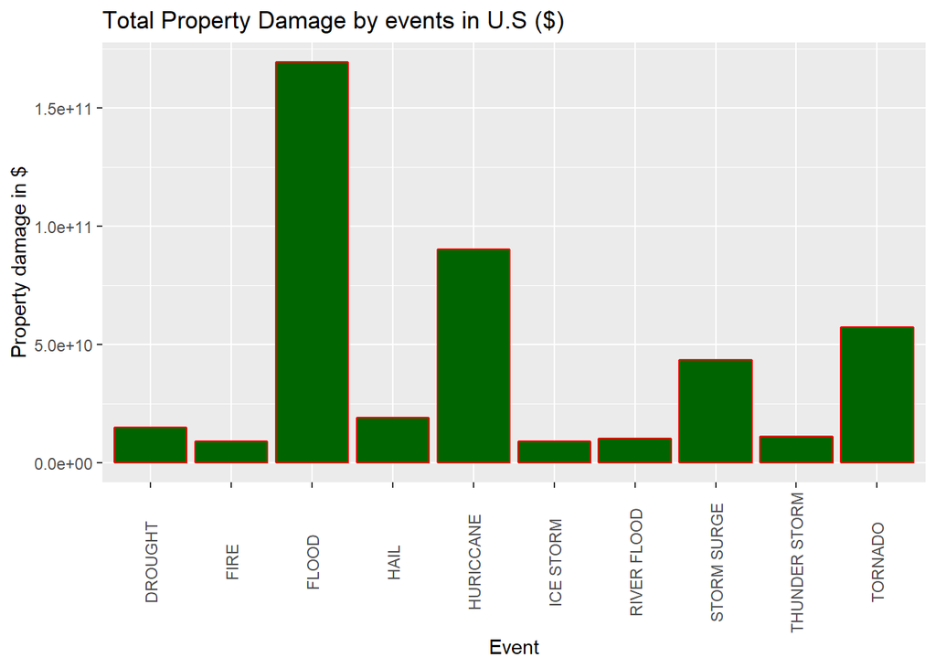

```r
graf_totalpropertydamage
```

This graphic shows us that related to the total property damage, the most harmful was the FLOODS event.

#### Plot of top 10 property damage:

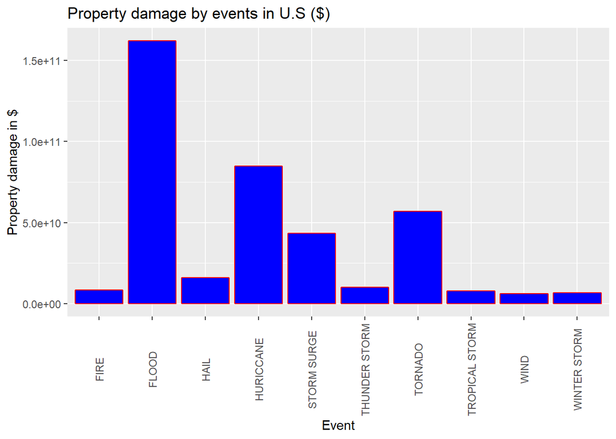

```r
graf_propdamage <- ggplot(head(event_total[order(event_total$Property, decreasing = TRUE),],10), aes(x = Event, y = Property)) +
        geom_bar(stat = "identity",color = "red",fill="blue") +
        ylab("Property damage in $") +
        ggtitle("Property damage by events in U.S ($)") +
        theme(axis.text.x = element_text(angle = 90, vjust = .5))
graf_propdamage
```

Related only to the property damage, we can see that FLOODS event was the worst, from the graphic above.

#### Plot of top 10 crop damage:

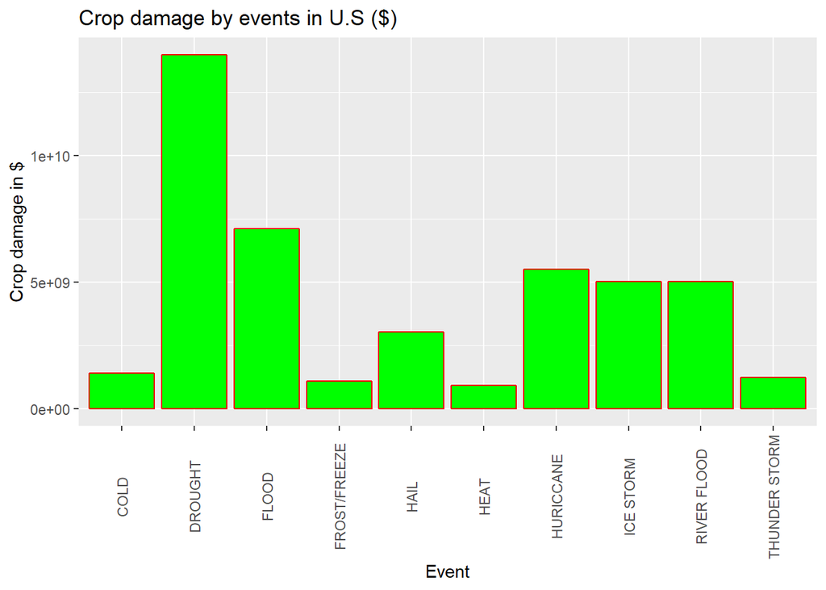

```r
graf_cropdamage <- ggplot(head(event_total[order(event_total$Crop, decreasing = TRUE),],10), aes(x = Event, y = Crop)) +
        geom_bar(stat = "identity",color = "red",fill="green") +
        ylab("Crop damage in $") +
        ggtitle("Crop damage by events in U.S ($)") +
        theme(axis.text.x = element_text(angle = 90, vjust = .5))
graf_cropdamage
```

Related only to the crop damage, we can see that DROUGHTS event was the worst, from the graphic above.

#### Ordering the data by personal damage:

```r
event_total_ordered2 <- event_total[order(event_total$PersonalDamage, decreasing = TRUE),]
head(event_total_ordered2)
```

```
##             Event     Property       Crop PropertyDamage Injuries
## 467       TORNADO  56947380677  414953270    57362333947    91346
## 172          HEAT     20325750  904463500      924789250     9224
## 455 THUNDER STORM   9962703102 1225458988    11188162090     9508
## 112         FLOOD 162072390896 7099131600   169171522496     8574
## 243     LIGHTNING    930379430   12092090      942471520     5230
## 554          WIND   6191755283  757115400     6948870683     1859
##     Fatalities PersonalDamage
## 467       5633          96979
## 172       3119          12343
## 455        710          10218
## 112       1488          10062
## 243        816           6046
## 554        429           2288
```

#### Checking the top 10 personal damage by event and plotting it:

```r
head(event_total_ordered2,10)
```

```
##             Event     Property       Crop PropertyDamage Injuries
## 467       TORNADO  56947380677  414953270    57362333947    91346
## 172          HEAT     20325750  904463500      924789250     9224
## 455 THUNDER STORM   9962703102 1225458988    11188162090     9508
## 112         FLOOD 162072390896 7099131600   169171522496     8574
## 243     LIGHTNING    930379430   12092090      942471520     5230
## 554          WIND   6191755283  757115400     6948870683     1859
## 212     ICE STORM   3944927860 5022113500     8967041360     1975
## 108          FIRE   8491563500  402781630     8894345130     1606
## 556  WINTER STORM   6688497251   26944000     6715441251     1321
## 197     HURICCANE  84756180010 5515292800    90271472810     1328
##     Fatalities PersonalDamage
## 467       5633          96979
## 172       3119          12343
## 455        710          10218
## 112       1488          10062
## 243        816           6046
## 554        429           2288
## 212         89           2064
## 108         90           1696
## 556        206           1527
## 197        135           1463
```

```r
graf_totalpersonaldamage <- ggplot(head(event_total_ordered2,10), aes(x = Event, y = PersonalDamage)) +
        geom_bar(stat = "identity",color = "red",fill="grey") +
        ylab("Total of personal damage") +
        ggtitle("Total Personal Damage by events in U.S") +
        theme(axis.text.x = element_text(angle = 90, vjust = .5))
```

#### Plot of total personal damage by event type

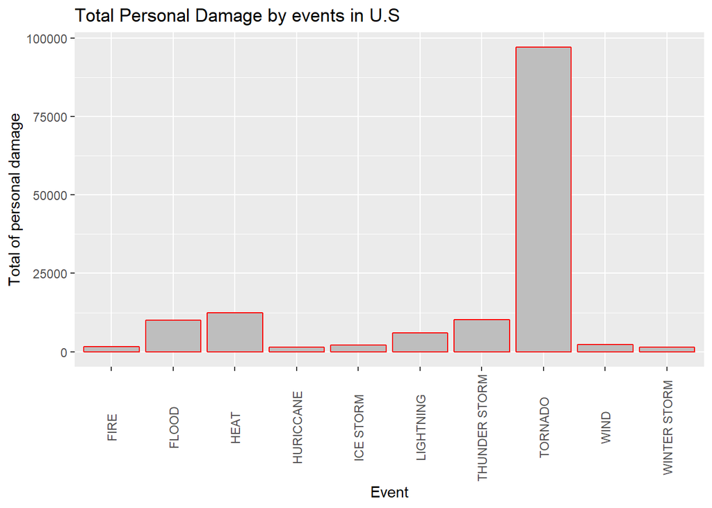

```r
graf_totalpersonaldamage
```

From the analysis of the graphic above, we can see that TORNADO was the event most harmful to the personal health.

#### Plot of injuries by event (top 10):

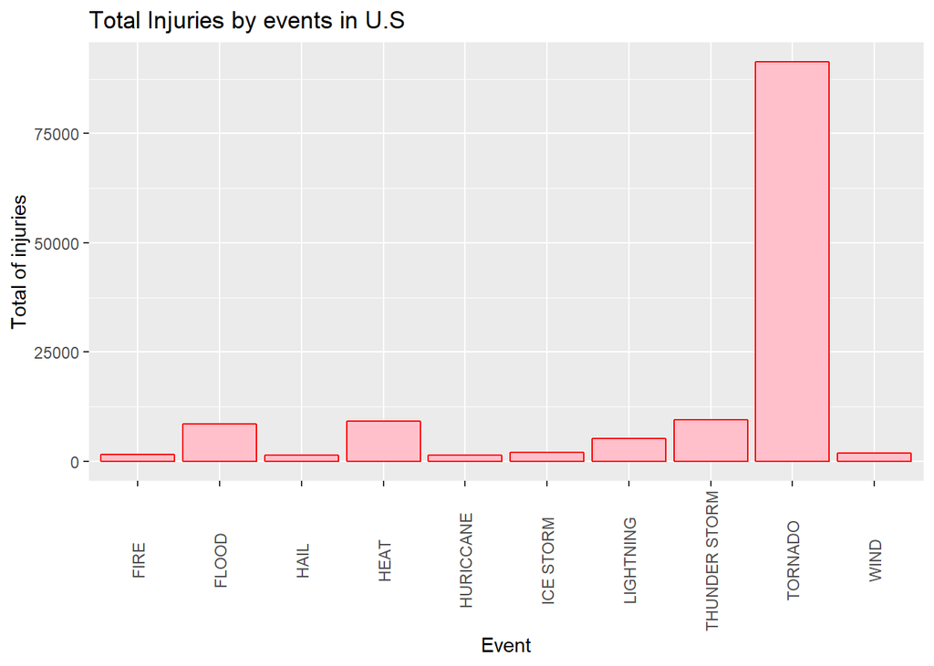

```r
graf_injuries <- ggplot(head(event_total[order(event_total$Injuries, decreasing = TRUE),],10), aes(x = Event, y = Injuries)) +
        geom_bar(stat = "identity",color = "red",fill="pink") +
        ylab("Total of injuries") +
        ggtitle("Total Injuries by events in U.S") +
        theme(axis.text.x = element_text(angle = 90, vjust = .5))
graf_injuries
```

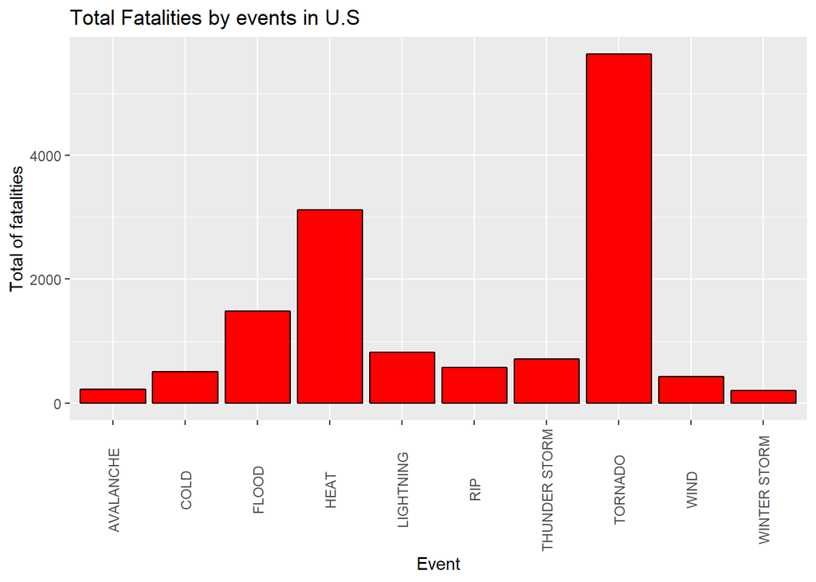

```r
graf_fatalities <- ggplot(head(event_total[order(event_total$Fatalities, decreasing = TRUE),],10), aes(x = Event, y = Fatalities)) +
        geom_bar(stat = "identity",color = "black",fill="red") +
        ylab("Total of fatalities") +
        ggtitle("Total Fatalities by events in U.S") +
        theme(axis.text.x = element_text(angle = 90, vjust = .5))
graf_fatalities
```

TORNADO was the event that caused most fatalities in the population. According to the graphic above.

## Results

From this analysis, we can answer the questions about which types of events are most harmful with respect to population health. In the plot of total personal damage by event type, we can see that tornado was the event type most harmful to the people health, across the United States.

Related to the second question, across the United States, which types of events have the greatest economic consequences, the plot of total property damage by event type shows us that the floods are the events that generated greatest economic consequences, followed by hurricanes and tornados.